# Week 01 Notes

#### Date: January 10, 2024

#### Name: Nic Zaparniuk

#### Partner: Emily Li

### Experiment: Measuring the Gas Constant

**Objective:**

The experimental set-up suggests an experiment where we find the gas constant of air by using the given materials and how it relates to the ideal gas law.

**Hypothesis:**

I hypothesize that the the ideal gas law has a linear relationship with the gas constant.

**Research Question (tentative):**

What is the relationship between the Applied external force and the gas constant?

Figure 1

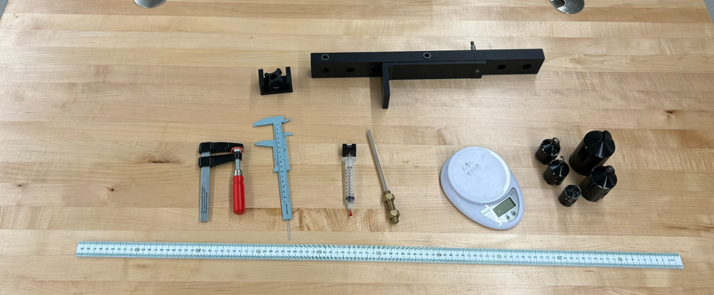

(a) Components of Apparatus

[figure not shown]

(b) Completed Apparatus

**Materials Used:**

- $1x100g$ Weight
- $2x200g$ Weight
- $1x500g$ Weight
- $1x1000g$ Weight
- $5Kg$ WH-BO5 Electronic Scale
- $1x10ml$ Syringe with stopper and clip
- $1x1m$ Ruler

**Measurement Range**

The syringe can hold a volume from $0-10ml$

The Kaliper has a measurement range from $0-160mm$

**What are the sources of uncertainty, how do you quantify them, and how can you minimize them minimize them?**

- There may not be a perfect seal on the syringe so the number of moles could change between each experiment which could result in uncertainty in the gas constant.
- There could be a small resulting change internal temperature due to a change in volume/pressure resulting in uncertainty in the gas constant
- There can be a small unceratainty in the mass resulting in uncertainty in the recorded pressure which means an uncertainty in the measured gas constant. This can be minimized by using the apparatus built in order to accurately measure the ratio between scale values and force applied resulting in a smaller uncertainty.
- Using the Kaliper to measure volume//area there is still a small amount of measuremet uncertainty. This can be minimized by taking multiple measurements of the volume and area in order to reduce the uncertainty.

**Some Questions to Answer**

- What is the basic equation you are starting from?

The Ideal Gas Law where $PV = nRT $

rearranged so that $P = R\frac{nT}{V} $

Where:

- $P$ = pressure of the gas
- $V$ = volume of the gas
- $n$ = number of moles of the gas
- $R$ = ideal gas constant
- $T$ = temperature of the gas (in Kelvin)

**How can syringe be used to perform measurements relevent to this? Draw a free-body diagram to ensure you have a good understanding of the system.**

- A syringe can be used to trap a certain volume of gas. Then by pulling or pushing on the syringe you can change the volume and then change the pressure of the gas.

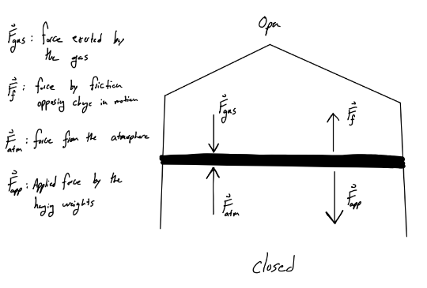

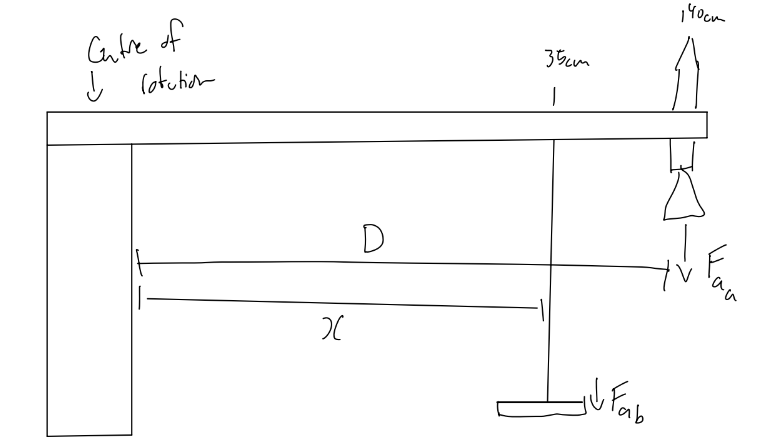

**What other equations and measurements are needed?**

- $P= \frac{F_{\text{app}}}{A}$
- $F=mg$
- $\tau=F_{\text{app1}}D_1$
- $\tau=F_{\text{app2}}D_2$
- $F_{\text{app1}} = \frac{D_2}{D_1} F_{\text{app2}}$
- Newtons Second Law $\sum F=ma$ which can be written as,

$F_{\text{atm}} - F_{\text{gas}} - F_{\text{app}} \pm F_f=0$

- $R=K_b*N_a$ ($K_b=$boltzmann constant, $N_a=$Avogadro number) where $R=8.31436261815324 JK^-1mol^-1$
- $n_{\text{gas}}=\frac{\rho V}{M_{\text{air}}}$ , where $\rho$=density of air, $V$= volume of air, and $M_{\text{air}}$= molar mass of air

**How can you bring all of this theory together in a way that lets you plot data and extract the gas constant?**

- By measuring the initial weight of the mass used and then finding the torque associated with radius. We can decrease the uncertainty of the force associated with the mass hanging from the syringe. Giving a more precise value for the applied force on the syringe
- A seen in figure 1 (b), the weight being measured on the scale, and therefore the force being applied to it, is not the same as that being experienced by the syringe. This is due to the distance from the pivot point being different for each point. Therefore, in order to find what the force being applied to the syringe is we will have to use several equations, $\tau=F_{\text{app1}}D_1$ and $\tau=F_{\text{app2}}D_2$. Because the torque is equal these formulae can be equated resulting in the followign equation to find the force being applied to the syringe $F_{\text{app1}} = \frac{D_2}{D_1} F_{\text{app2}}$
- By using newtons second law we can obtain the equation $F_{\text{atm}} - F_{\text{gas}} - F_{\text{app}} \pm F_f=0$. As we are trying to calculate the gas constant knowing the system will be in equalibrium we can determine that the friction acting upward will be the same as the friciton acting downward resulting in $F_f=0$. Furthermore, we can use the equation $P= \frac{F_{\text{app}}}{A}$ to determine that the applied force will be equal to the force from the gas resulting in the equation $P= \frac{F_{\text{gas}}}{A}$. Substituting this value into the rearanged ideal gas law we will get the equation, $F_{\text{gas}} = \frac{An_{\text{gas}}RT}{V_{\text{gas}}} $.
- Now, that we have this equation we can substitute our values back into newtons second law resulting in the following equation $F_{\text{app}} = -\frac{An_{\text{gas}}RT}{V_{\text{gas}}} + P_{\text{atm}}A$. This equation is similar to the linear graph of y=mx+b, where in this case we will plot $F_{\text{app}}$ vs $\frac{1}{V_{\text{gas}}} $ with a slope ${-An_{\text{gas}}RT}$ and an intercept of $P_{\text{atm}}A$

### General Notes

We originally started by having our pin through the center circle; however, we noticed that the further pin and another part fit well. The pin and the scale are about the same height needed so we put that through the middel hole.

We know that the syringe has a volume and an internal pressure. We want to use the weights to pull on the bottom of the syringe in order to change the volume (dependant variable) and therefore change the pressure inside the syringe(independant variable). The amount of gas inside the syringe shouldn't change and we can use it as an estimate. (I think)

Figure 1 (b) shows the completed aparatus after about 30 minutes of trying to figure out how the pieces were supposed to fit together.

The method for finding the gas constant $R$ was thought of after the lab period

We still need to get data on the Temperature of the room $T$, moles of gas present $n_{\text{gas}}$, and the volume $V_{\text{gas}}$ in the syringe

We plan on making two different plots; one showing the relationship between The applied force on the syringe and the weight used, as well as a graph plotting the applied force against the inverse of the volume of the syringe which will make it possible to extract the gas constant. This will most likely be done using a linear model and residuals will be plotted using the least-squares method which can be imported from the scipy curve fit library.

Plotting the Applied force on the syringe vs the scale reading we can find the slope between these which can be used as a conversion factor for the applied force. Using the set weights that have been provided can be used to help reduce the uncertainty in the conversion factor.

### Measurements from Today

syringe diameter = $10.8mm +/- 0.5mm$ - found using Kaliper

area of cross section = $91.6mm +/- 0.5mm$ - using equation $area=\pi r^2$

Radius of hanging weight to pivot =0.40m +/- 0.005m

Radius of Rod to pivot = 0.35m +/- 0.005m

#### Change in Volume Starting at 1mL (uncertainties still need to be calculated)

1. 100g -> 0ml
2. 200g -> 0.07ml
3. 500g -> 0.2ml
4. 1000g -> 1.2ml

```python
#constants
ratio=0.35/0.4 # ratio between the lengths
```

```python
Fapp1=ratio*(0.546*9.81)
Fapp2=ratio*(0.112*9.81)
Fapp3=ratio*(0.221*9.81)
Fapp4=ratio*(1.115*9.81)

print(Fapp1)
print(Fapp2)
print(Fapp3)
print(Fapp4)
```

```
4.6867275
0.96138
1.89700875
9.57088125
```